# Tek Değişkenli Zaman Serisi Analizi

### **Tahmin Değerleri**

```r
ongoru <- forecast(Winters2,h=12)

ongoru[["mean"]]
```

```
##          Jan     Feb     Mar     Apr     May     Jun     Jul     Aug     Sep
## 2024 1847630 1721407 1797963 1726962 1730021 1636771 1699620 1774461 1788347
##          Oct     Nov     Dec
## 2024 1857313 1816958 1868307
```

```r
ongoru
```

```
##          Point Forecast   Lo 80   Hi 80   Lo 95   Hi 95
## Jan 2024        1847630 1802800 1892460 1779068 1916191
## Feb 2024        1721407 1670620 1772194 1643735 1799079
## Mar 2024        1797963 1736939 1858987 1704635 1891291
## Apr 2024        1726962 1661581 1792343 1626971 1826954
## May 2024        1730021 1658388 1801655 1620467 1839575
## Jun 2024        1636771 1563655 1709887 1524949 1748592
## Jul 2024        1699620 1618529 1780710 1575602 1823637
## Aug 2024        1774461 1684731 1864192 1637230 1911692
## Sep 2024        1788347 1693081 1883613 1642650 1934043
## Oct 2024        1857313 1753598 1961027 1698695 2015930
## Nov 2024        1816958 1711033 1922883 1654959 1978957
## Dec 2024        1868307 1754985 1981629 1694996 2041618
```

Model kullanılarak yapılan tahminlerin %80 güven düzeyindeki alt sınırı (Lo80), üst sınırı (Hi80), %95 güven düzeyindeki alt sınırı (Lo95), üst sınırı (Hi95) ve nokta tahmin değerleri yukarıda sunulmuştur.

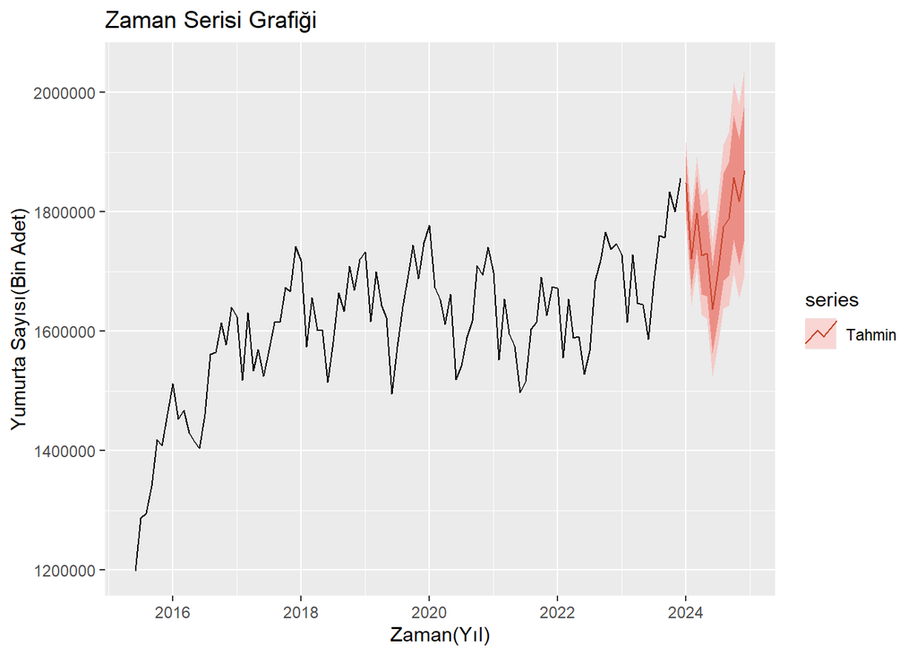

```r
autoplot(veri_ts2) +
  autolayer(ongoru, series = "Tahmin", PI=TRUE) +
  ggtitle("Zaman Serisi Grafiği") +
  xlab("Zaman(Yıl)") +
  ylab("Yumurta Sayısı(Bin Adet)")
```

## **Mevsimsel ARIMA Modelleri (SARIMA)**

SARIMA modeli, ARIMA modelinin bir genişletmesi olup, mevsimsel bileşenleri de içerecek şekilde modelin parametrelerini düzenler. SARIMA, mevsimsel özellikleri AR, MA, ve differencing (farklılaştırma) terimleri ile doğrudan modele dahil eder.

SARIMA modelinin genel formu şu şekildedir:

SARIMA(p,d,q)(P,D,Q)

İlk adım olarak, veri setinin zaman serisi grafiği incelenmiştir. Zaman serisi grafiği üzerinde görsel bir inceleme yapıldığında, mevsimsel dalgalanmalar ve trend gibi yapılar gözlemlenmiştir. Bu yapıların varlığı, serinin durağan olmadığına işaret etmektedir. Zaman serisinin durağan hale getirilmesi için, trendin ve mevsimselliğin ortadan kaldırılması gerekmektedir. Zaman serisini durağanlaştırmak amacıyla, hem trend farkı hem de mevsimsel fark alınmıştır. Bu işlem, zaman serisinin durağan hale gelmesini sağlamak için gereklidir. Trend farkı almak, serinin zamanla artan veya azalan yapısını ortadan kaldırırken; mevsimsel fark almak, belirli bir periyot boyunca tekrar eden döngüsel yapıları düzeltir.

```r
verisar = ts(veri, start = c(2015,6),  frequency =12)
```

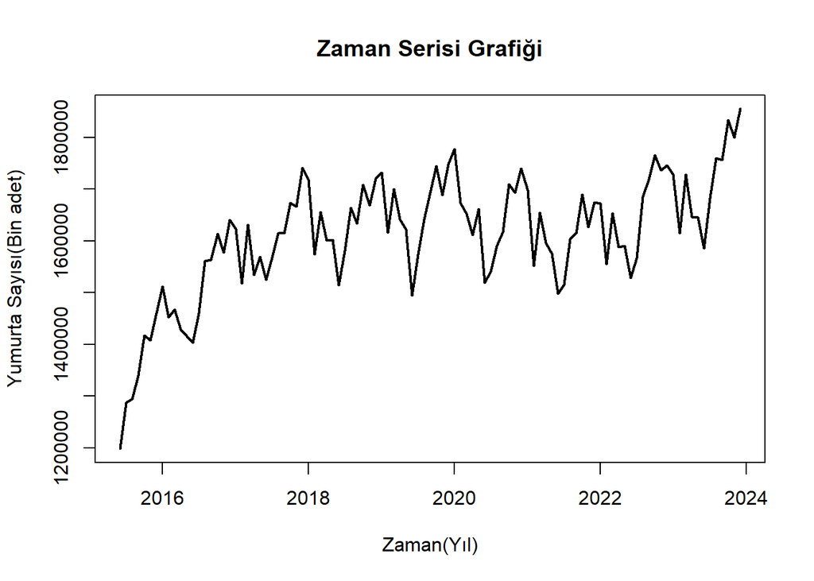

```r
ts.plot(verisar,main="Zaman Serisi Grafiği", xlab="Zaman(Yıl)", ylab="Yumurta Sayısı(Bin adet)", lwd=2)
```

Serinin genel yönelimindeki (trend) değişiklikleri ortadan kaldırmak için birinci dereceden fark alınmıştır. Bu işlem, trendi etkili bir şekilde gidererek veriyi daha düzgün hale getirmiştir.

Serideki mevsimsel bileşenleri ortadan kaldırmak amacıyla birinci dereceden mevsimsel fark alınmıştır. Bu, mevsimsel dalgalanmaları ortadan kaldırarak seriyi daha düzgün ve durağan hale getirmiştir.

Seriyi durağan hale getirmek için birinci dereceden farkların alınması yeterli olmuştur. Bu durumda ilk parametre değerlerimiz d=1, D=1 olarak belirlenmiştir.ACF ve PACF grafiklerinin incelenmesi, ARIMA modelinin parametrelerinin seçilmesinde önemli bir adımdır.

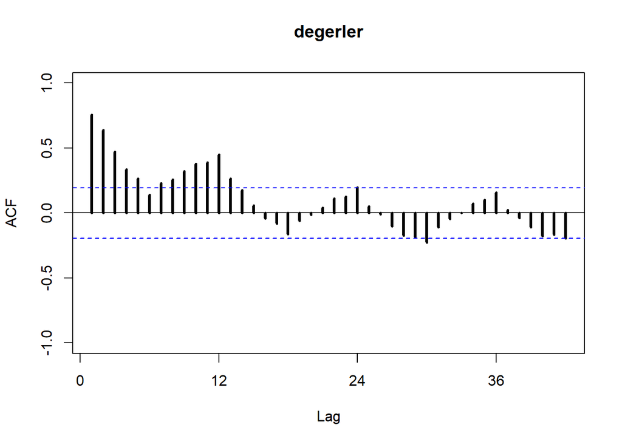

```r
Acf(verisar,lag.max = 42,  ylim=c(-1,1), lwd=3)
```

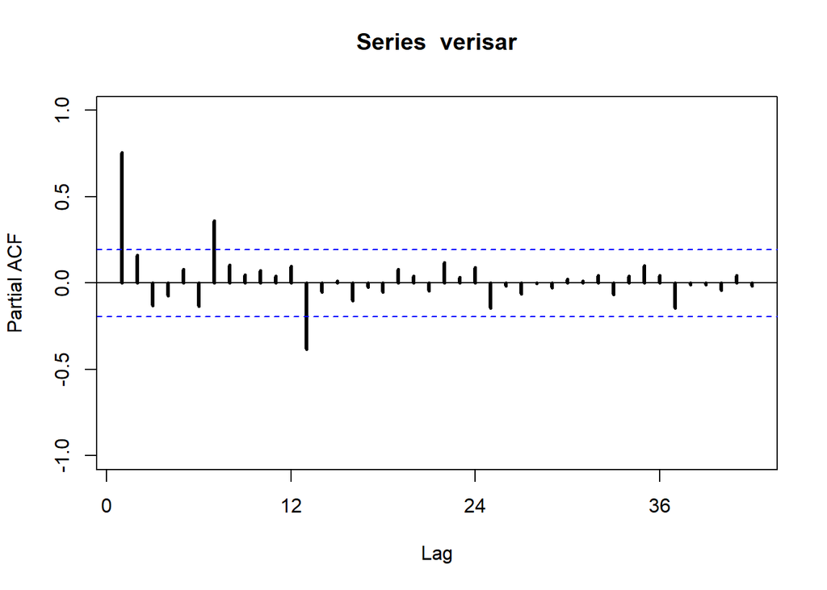

```r
Pacf(verisar,lag.max = 42,  ylim=c(-1,1), lwd=3)
```

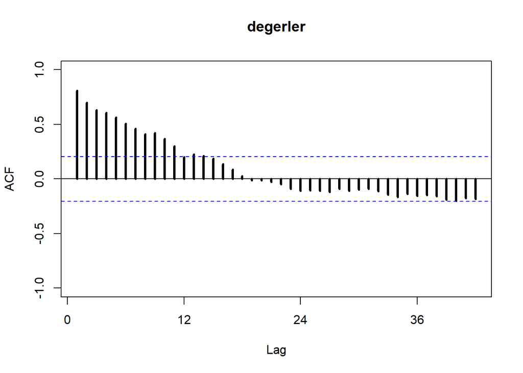

```r
Acf(diff(verisar,12),lag.max = 42, ylim=c(-1,1), lwd=3)
```

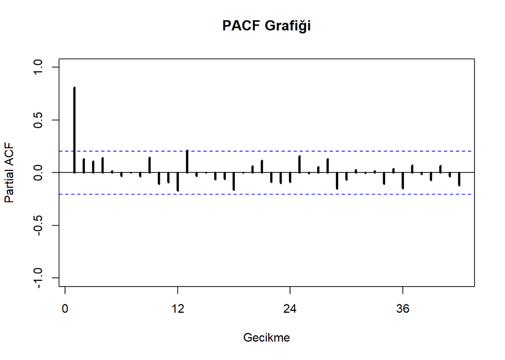

```r
Pacf(diff(verisar,12),lag.max = 42, ylim=c(-1,1), lwd=3, main = "PACF Grafiği", xlab = "Gecikme")
```

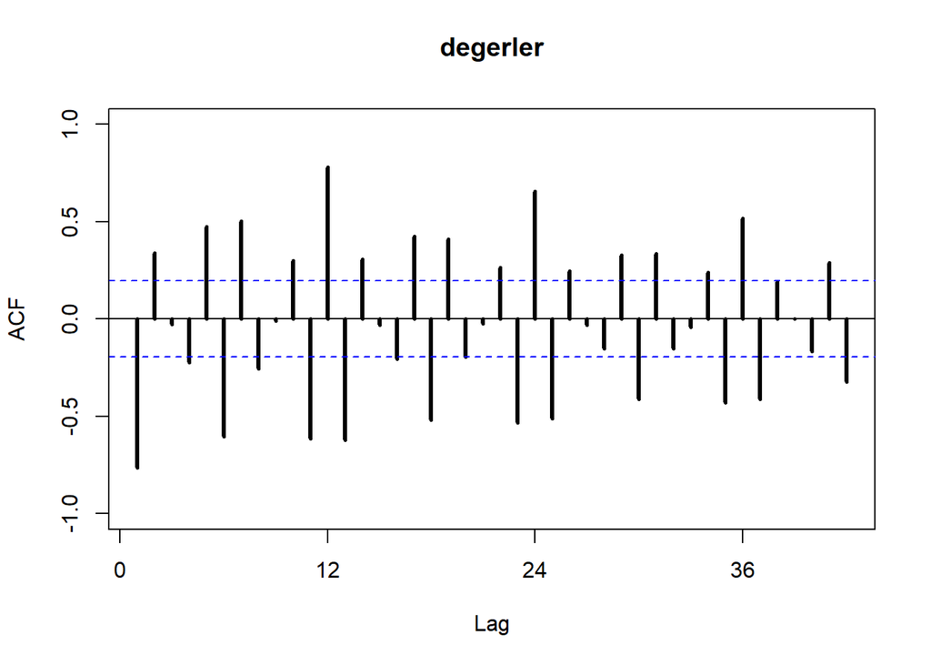

```r
Acf(diff(diff(verisar,,2,12)),lag.max = 42, ylim=c(-1,1), lwd=3)
```

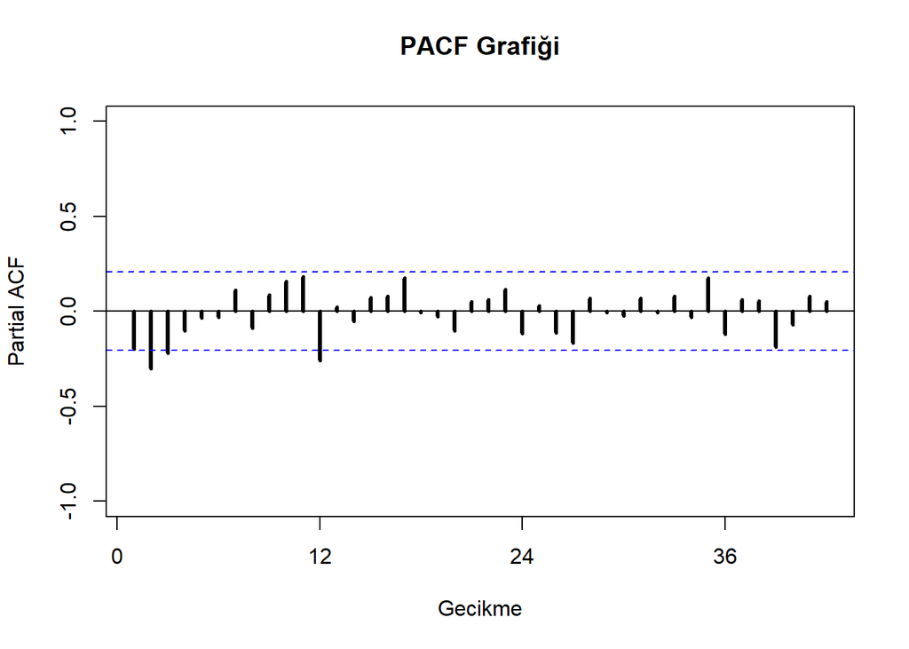

```r
Pacf(diff(diff(verisar,12)),lag.max = 42, ylim=c(-1,1), lwd=3, main = "PACF Grafiği", xlab = "Gecikme")
```

ACF ve PACF grafiklerinden elde edilen bulgulara dayanarak, q parametresinin en fazla “1”, p parametresinin ise en fazla “2” değerini alabileceğine karar verilmiştir.

Yukarıda belirtilen parametre kombinasyonlarıyla toplamda on farklı ARIMA modeli test edilmiştir. Bu modeller arasından beş tanesi istatistiksel olarak anlamlı bulunmuş ve test sonuçları aşağıda sunulmuştur.

### **Anlamlı Bulunan Modeller**

*BIC = 2154*

```r
deneme_arima2 <- Arima(verisar, order = c(0,1,1), seasonal= c(1,1,0), include.constant=TRUE)
coeftest(deneme_arima2)
```

```
##
## z test of coefficients:
##
##      Estimate Std. Error z value  Pr(>|z|)
## ma1  -0.37055    0.12887 -2.8754 0.0040348 **
## sar1 -0.39869    0.10598 -3.7618 0.0001687 ***
## ---
## Signif. codes:  0 '***' 0.001 '**' 0.01 '*' 0.05 '.' 0.1 ' ' 1
```

```r
summary(deneme_arima2)
```

```
## Series: verisar
## ARIMA(0,1,1)(1,1,0)[12]
##
## Coefficients:
##           ma1     sar1
##       -0.3706  -0.3987
## s.e.   0.1289   0.1060
##
## sigma^2 = 1.253e+09:  log likelihood = -1070.48
## AIC=2146.97   AICc=2147.25   BIC=2154.47
##
## Training set error measures:
##                     ME     RMSE      MAE        MPE     MAPE      MASE
## Training set -2365.122 32715.03 24416.37 -0.1677534 1.502921 0.3856471
##                   ACF1
## Training set 0.0778036
```

*BIC = 2162*

```r
deneme_arima3 <- Arima(verisar, order = c(0,1,1), seasonal= c(0,1,0), include.constant=TRUE)
coeftest(deneme_arima3)
```

```
##
## z test of coefficients:
##
##     Estimate Std. Error z value  Pr(>|z|)
## ma1 -0.49689    0.11505 -4.3189 1.568e-05 ***
## ---
## Signif. codes:  0 '***' 0.001 '**' 0.01 '*' 0.05 '.' 0.1 ' ' 1
```

```r
summary(deneme_arima3)
```

```
## Series: verisar
## ARIMA(0,1,1)(0,1,0)[12]
##
## Coefficients:
##           ma1
##       -0.4969
## s.e.   0.1151
##
## sigma^2 = 1.448e+09:  log likelihood = -1076.55
## AIC=2157.11   AICc=2157.25   BIC=2162.11
##
## Training set error measures:
##                     ME     RMSE      MAE        MPE     MAPE      MASE
## Training set -2269.303 35376.99 27056.42 -0.1607267 1.664266 0.4273456
##                   ACF1
## Training set 0.1208607
```

*BIC=2155.86*

```r
deneme_arima4 <- Arima(verisar, order = c(2,1,0), seasonal= c(1,1,0), include.constant=TRUE)
coeftest(deneme_arima4)
```

```
##
## z test of coefficients:
##
##      Estimate Std. Error z value  Pr(>|z|)
## ar1  -0.22761    0.10276 -2.2149 0.0267647 *
## ar2  -0.26780    0.10369 -2.5827 0.0098026 **
## sar1 -0.40700    0.10640 -3.8251 0.0001307 ***
## ---
## Signif. codes:  0 '***' 0.001 '**' 0.01 '*' 0.05 '.' 0.1 ' ' 1
```

```r
summary(deneme_arima4)
```

```
## Series: verisar
## ARIMA(2,1,0)(1,1,0)[12]
##
## Coefficients:
##           ar1      ar2     sar1
##       -0.2276  -0.2678  -0.4070
## s.e.   0.1028   0.1037   0.1064
##
## sigma^2 = 1.222e+09:  log likelihood = -1068.93
## AIC=2145.86   AICc=2146.33   BIC=2155.86
##
## Training set error measures:
##                     ME     RMSE      MAE        MPE    MAPE      MASE
## Training set -2285.442 32132.41 23499.35 -0.1624452 1.44884 0.3711631
##                     ACF1
## Training set -0.04688018
```

*BIC=2164.08*

```r
deneme_arima9 <- Arima(verisar, order = c(2,1,0), seasonal= c(0,1,0), include.constant=TRUE)
coeftest(deneme_arima9)
```

```
##
## z test of coefficients:
##
##     Estimate Std. Error z value Pr(>|z|)
## ar1 -0.25828    0.10076 -2.5634  0.01036 *
## ar2 -0.31430    0.10283 -3.0564  0.00224 **
## ---
## Signif. codes:  0 '***' 0.001 '**' 0.01 '*' 0.05 '.' 0.1 ' ' 1
```

```r
summary(deneme_arima9)
```

```
## Series: verisar
## ARIMA(2,1,0)(0,1,0)[12]
##
## Coefficients:
##           ar1      ar2
##       -0.2583  -0.3143
## s.e.   0.1008   0.1028
##
## sigma^2 = 1.425e+09:  log likelihood = -1075.29
## AIC=2156.58   AICc=2156.86   BIC=2164.08
##
## Training set error measures:
##                     ME     RMSE      MAE        MPE     MAPE      MASE
## Training set -1726.544 34889.92 26171.99 -0.1262105 1.607969 0.4133764
##                     ACF1
## Training set -0.07448556
```

*BIC=2156.49*

```r
deneme_arima10<- Arima(verisar, order = c(2,1,0), seasonal= c(2,1,0), include.constant=TRUE)
coeftest(deneme_arima10)
```

```
##
## z test of coefficients:
##
##      Estimate Std. Error z value  Pr(>|z|)
## ar1  -0.23494    0.10316 -2.2775   0.02276 *
## ar2  -0.25686    0.10456 -2.4565   0.01403 *
## sar1 -0.50938    0.11830 -4.3057 1.664e-05 ***
## sar2 -0.23366    0.11524 -2.0276   0.04260 *
## ---
## Signif. codes:  0 '***' 0.001 '**' 0.01 '*' 0.05 '.' 0.1 ' ' 1
```

```r
summary(deneme_arima10)
```

```
## Series: verisar
## ARIMA(2,1,0)(2,1,0)[12]
##
## Coefficients:
##           ar1      ar2     sar1     sar2
##       -0.2349  -0.2569  -0.5094  -0.2337
## s.e.   0.1032   0.1046   0.1183   0.1152
##
## sigma^2 = 1.166e+09:  log likelihood = -1067
## AIC=2144   AICc=2144.71   BIC=2156.49
##
## Training set error measures:
##                     ME    RMSE      MAE        MPE     MAPE      MASE
## Training set -3129.212 31204.5 22725.45 -0.2147529 1.403074 0.3589397
##                     ACF1
## Training set -0.04478997
```

Yukarıda, istatistiksel olarak anlamlı bulunan beş modelin istatistikleri verilmiştir. En iyi sonuç veren modeli belirlemek için Bayes Bilgi Kriterinden (BIC) yararlanılmıştır. Beş modelin BIC değerlerine bakıldığında, en küçük değere sahip model “BIC = 2154,47” değeri ile ARIMA(0,1,1)(1,1,0)[12] parametrelerine sahip modeldir.

En iyi model belirlendiğine göre şimdi modelin geçerliliği kontrol edilecektir. Bu amaçla, tahmin serisi ile orijinal serinin zaman grafiği, hata serisinin ACF grafiği ve Box-Ljung test istatistiği aşağıda sunulmuştur.

```r
tahmin = deneme_arima2[["fitted"]]
hata = deneme_arima2[["residuals"]]
```

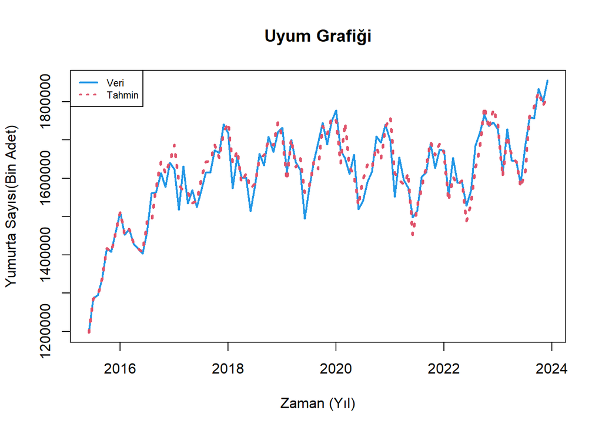

```r
plot(window(verisar), main = "Uyum Grafiği",
      xlab="Zaman (Yıl)", ylab="Yumurta Sayısı(Bin Adet)",lty=1, col=4, lwd=2)
lines(window(tahmin) ,lty=3,col=2,lwd=3)
legend("topleft",c(expression(paste("Veri")),
               expression(paste("Tahmin"))),
       lwd=c(2,2),lty=c(1,3), cex=0.7, col=c(4,2))
```

Grafik incelendiğinde, orijinal seri ile tahmin serisinin yeteri kadar uyum içerisinde olduğu söylenebilir. Fakat daha kesin kararlar verebilmek için hata serisinin ACF grafiği ve BoxLjung testi incelenecektir.

### **ACF,PACF, Artıkların Dağılım Grafiği ve Box-Lung Testi**

```r
Box.test (hata, lag = 42, type = "Ljung")
```

```
##
##  Box-Ljung test
##
## data:  hata
## X-squared = 54.408, df = 42, p-value = 0.09496
```

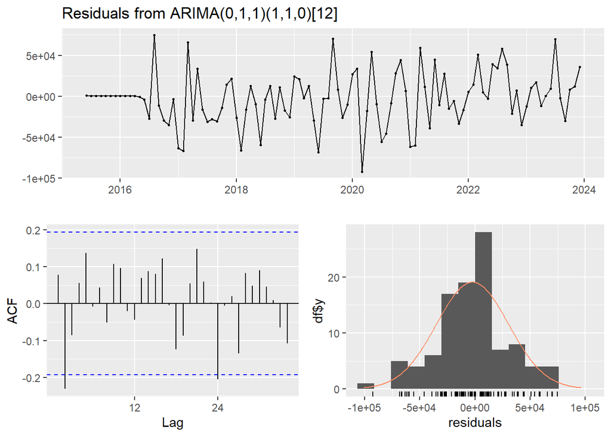

```
##
##  Ljung-Box test
##
## data:  Residuals from ARIMA(0,1,1)(1,1,0)[12]
## Q* = 23.2, df = 19, p-value = 0.2287
##
## Model df: 2.   Total lags used: 21
```

```r
checkresiduals(deneme_arima2)
```

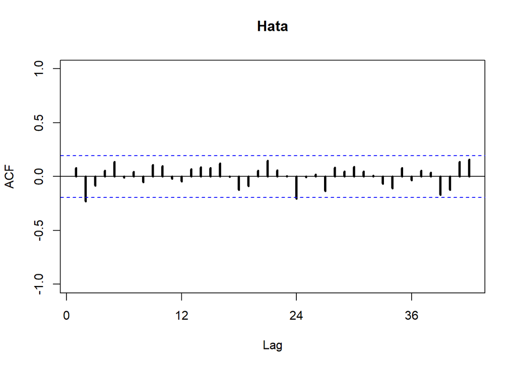

```r
Acf(hata,main="Hata", lag.max = 42,  ylim=c(-1,1), lwd=3)
```

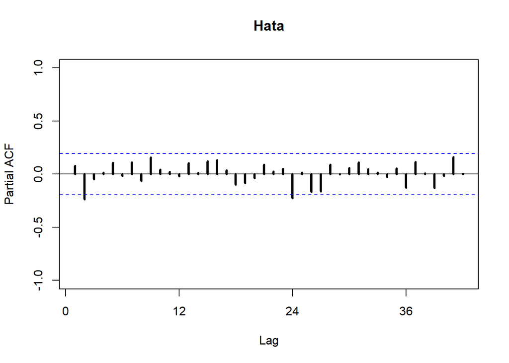

```r
Pacf(hata,main="Hata",lag.max = 42, ylim=c(-1,1), lwd=3)
```

Grafikler ve Box-Ljung test istatistiği incelendiğinde, artıkların zaman içerisinde rastgele dağıldığı ve gecikmeler arasında herhangi bir ilişki bulunmadığı sonucuna ulaşılmıştır. Bu nedenle, modelin incelenen veri seti için uygun olduğu ifade edilebilir.

### **Tahmin Değerleri**

```r
ongoru = forecast(deneme_arima2 , h=12)
ongoru["mean"]
```

```
## $mean
##          Jan     Feb     Mar     Apr     May     Jun     Jul     Aug     Sep
## 2024 1830934 1716096 1823293 1748329 1748248 1687653 1761861 1854680 1866432
##          Oct     Nov     Dec
## 2024 1931520 1899396 1936669
```

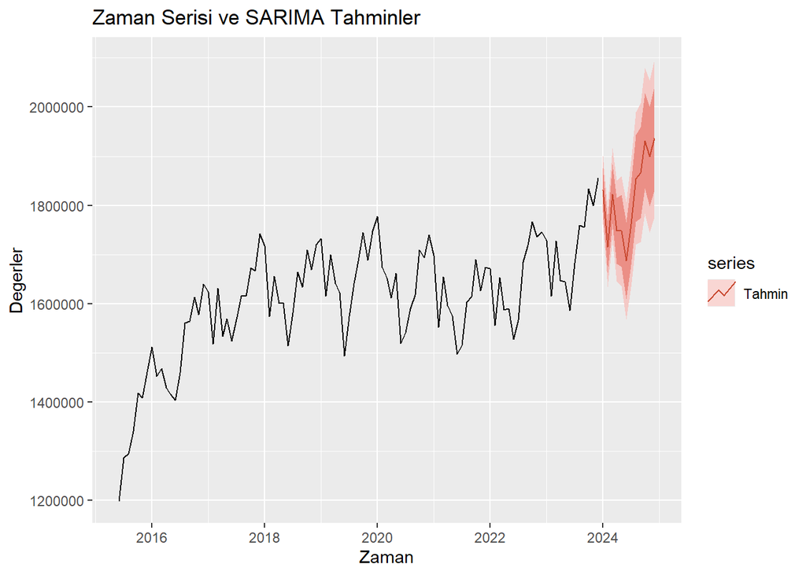

```r
autoplot(verisar) +
  autolayer(ongoru, series="Tahmin", PI=TRUE) +
  ggtitle("Zaman Serisi ve SARIMA Tahminler") +
  xlab("Zaman") +
  ylab("Degerler")
```

## **Kullanılan Modellerin Tahmin Değerleri ile Gerçek Değerlerin Karşılaştırılması**

Modelin geçerliliğini anlayabilmek için gerçek değerler ile tahmin değerlerinin çizgi grafiği, tahmin hatalarının dağılımı, ortalama mutlak hata(MAE), kök ortalama hata(RMSE) ve ortalama yüzde hata(MAPE) değerleri incelenmiştir. Elde edilen bulgular aşağıda sunulmuştur.

```r
original_values = ts(c(1838422, 1733464
, 1790081
, 1707799
, 1764629
, 1694374
, 1706493
, 1808368
, 1828030))

forecasted_values = ts(c(1830934 ,1716096 ,1823293 ,1748329, 1748248, 1687653, 1761861 ,1854680, 1866432))

forecasted_valueswinters = ts(c(1846160, 1728852, 1798002, 1732222, 1732595, 1647998, 1699930, 1774369, 1786176))
```

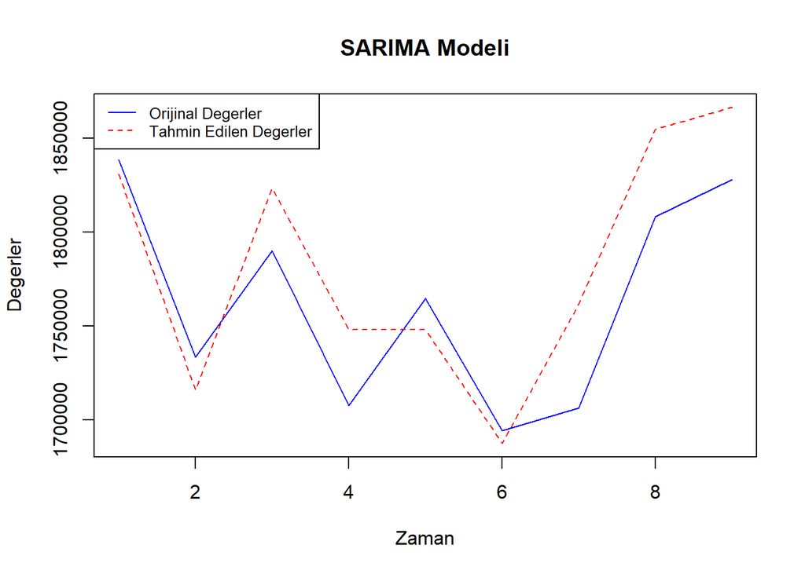

```r
plot(original_values, col = "blue", lty = 1, ylim = range(c(original_values, forecasted_values)),
     main = "SARIMA Modeli", xlab = "Zaman", ylab = "Degerler")
lines(forecasted_values, col = "red", lty = 2)
legend("topleft", legend = c("Orijinal Degerler", "Tahmin Edilen Degerler"),
       col = c("blue", "red"), lty = c(1, 2), cex = 0.8)
```

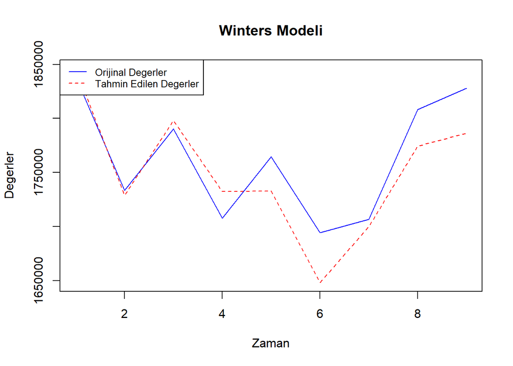

```r
plot(original_values, col = "blue", lty = 1, ylim = range(c(original_values, forecasted_valueswinters)),
     main = "Winters Modeli", xlab = "Zaman", ylab = "Degerler")
lines(forecasted_valueswinters, col = "red", lty = 2)
legend("topleft", legend = c("Orijinal Degerler", "Tahmin Edilen Degerler"),
       col = c("blue", "red"), lty = c(1, 2), cex = 0.8)
```

### **Ortalama Mutlak Hata (MAE)**

```r
mae = mean(abs(original_values - forecasted_values))
print(paste("Ortalama Mutlak Hata (MAE) SARIMA:", round(mae, 2)))
```

```
## [1] "Ortalama Mutlak Hata (MAE) SARIMA: 29086.89"
```

```r
mae = mean(abs(original_values - forecasted_valueswinters))
print(paste("Ortalama Mutlak Hata (MAE) Winters:", round(mae, 2)))
```

```
## [1] "Ortalama Mutlak Hata (MAE) Winters: 22835.56"
```

### **Kök Ortalama Kare Hata (RMSE)**

```r
rmse = sqrt(mean((original_values - forecasted_values)^2))
print(paste("Kok Ortalama Kare Hata (RMSE) SARIMA:", round(rmse, 2)))
```

```
## [1] "Kok Ortalama Kare Hata (RMSE) SARIMA: 33503.03"
```

```r
rmse = sqrt(mean((original_values - forecasted_valueswinters)^2))
print(paste("Kok Ortalama Kare Hata (RMSE) Winters:", round(rmse, 2)))
```

```
## [1] "Kok Ortalama Kare Hata (RMSE) Winters: 27624.56"
```

### **Ortalama Yüzde Hata (MAPE)**

```r
mape <- mean(abs((original_values - forecasted_values) / original_values) * 100)
print(paste("Ortalama Yuzde Hata (MAPE) SARIMA:", round(mape, 2), "%"))
```

```
## [1] "Ortalama Yuzde Hata (MAPE) SARIMA: 1.65 %"
```

```r
mape <- mean(abs((original_values - forecasted_valueswinters) / original_values) * 100)
print(paste("Ortalama Yuzde Hata (MAPE) WİNTERS:", round(mape, 2), "%"))
```

```
## [1] "Ortalama Yuzde Hata (MAPE) WİNTERS: 1.3 %"
```

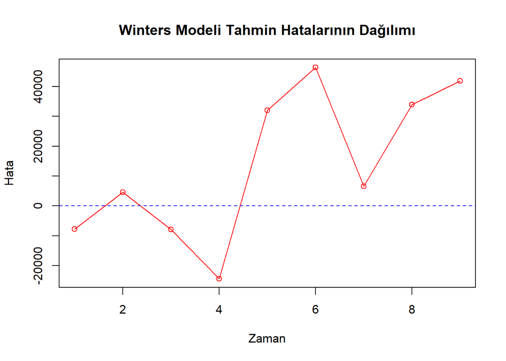

```r
residuals <- original_values - forecasted_valueswinters
plot(residuals, type = "o", col = "red", main = "Winters Modeli Tahmin Hatalarının Dağılımı",
     xlab = "Zaman", ylab = "Hata")
abline(h = 0, col = "blue", lty = 2)
```

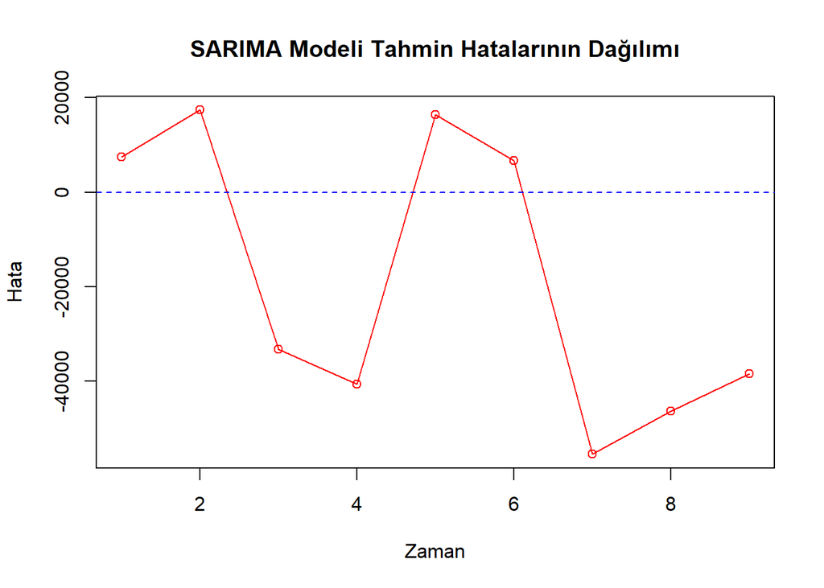

```r
residuals2 <- original_values - forecasted_values

plot(residuals2, type = "o", col = "red", main = "SARIMA Modeli Tahmin Hatalarının Dağılımı",
     xlab = "Zaman", ylab = "Hata")
abline(h = 0, col = "blue", lty = 2)
```

Winters modelleri ve SARIMA modelinin farklı teorik temellere sahip olması, birinin kesinlikle diğerinden üstün olduğu anlamına gelmez. Ancak, orijinal seri değerleri ile Toplamsal Winters modelinin tahmin edilen değerlerinin yer aldığı çizgi grafiğine bakıldığında, bu modelin SARIMA modeline göre daha uyumlu bir grafik sunduğu söylenebilir. Ayrıca, MAE, RMSE ve MAPE gibi hata metrik değerleri incelendiğinde, Toplamsal Winters modelinin daha düşük hata değerlerine sahip olduğu ve belirli dönemlerde SARIMA modelinden daha iyi tahminler yaptığı sonucuna varılabilir.

## **Sonuç**

Bu çalışma, Türkiye’nin tavuk yumurtası üretim verilerini incelemek ve bu veriler üzerinden geleceğe yönelik öngörülerde bulunmak amacıyla gerçekleştirilmiştir. Analizlerde kullanılan yöntemler, verilerin trend ve mevsimsel bileşenlerini anlamada etkili olmuş, en uygun modelin belirlenmesine olanak tanımıştır. Toplamsal Winters modeli, Çarpımsal Winters modeli ve SARIMA(0,1,1)(1,1,0) modeli incelenen veri seti ile uyumlu bulunmuştur. Sonuçlar, Toplamsal Winters modelinin, daha düşük hata metrikleri ve gerçek değerlere olan yakınlığıyla SARIMA ve Çarpımsal Winters modellerine kıyasla daha iyi tahmin performansı sunduğunu ortaya koymuştur. Bu bulgular, üretim ve gıda politikalarının planlanmasında ve kaynak tahsisinde karar alıcılara değerli bilgiler sunabilir. Gelecekte, daha karmaşık modellerin ve ek veri kaynaklarının dahil edilmesiyle tahmin doğruluğu daha da artırılabilir.